# SHC 798 R-code

Richard Lubega

2025-07-02

# Introduction

## R Markdown Preamble

See also the [**R Markdown Cookbook**](https://bookdown.org/yihui/rmarkdown-cookbook/))

## Including Plots - Example

### Another Plot

Let’s create another Test plot

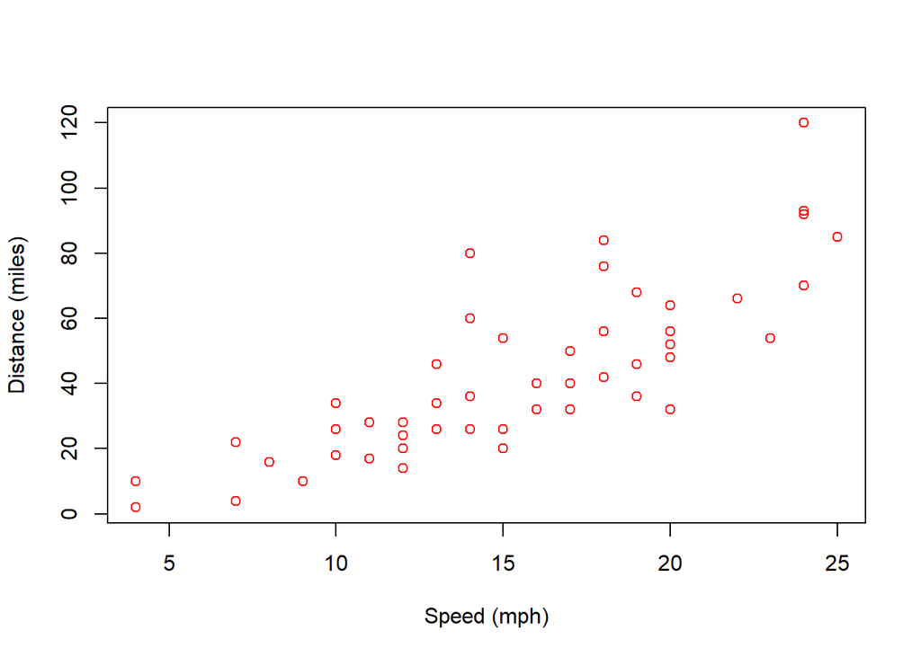

```r
plot(cars,  col = "red", xlab = "Speed (mph)", ylab = "Distance (miles)" )
```

A summary of the data frame is given below

```r
pacman::p_load(knitr)
kable(summary(cars))
```

|  | speed | dist |
| --- | --- | --- |
|  | Min. : 4.0 | Min. : 2.00 |
|  | 1st Qu.:12.0 | 1st Qu.: 26.00 |
|  | Median :15.0 | Median : 36.00 |
|  | Mean :15.4 | Mean : 42.98 |
|  | 3rd Qu.:19.0 | 3rd Qu.: 56.00 |
|  | Max. :25.0 | Max. :120.00 |

# Start of My SHC 798 R-code

## R basics

1. Why install [**Rtools**](https://cran.r-project.org/bin/windows/Rtools/)?
2. R Shiny [**Gallery**](http://shiny.rstudio.com/gallery/): There’s Shiny for R and Shiny for Python

## R Operations 1

What can be done?

```r
# R as a calculator
sqrt(12)
```

```
## [1] 3.464102
```

```r
x <- 3
y <- x^2
x+y
```

```
## [1] 12
```

```r
# Creating Vectors
v1 <- c(1,5, 80)
v1
```

```
## [1]  1  5 80
```

```r
v2 <- 2:11
v2
```

```
##  [1]  2  3  4  5  6  7  8  9 10 11
```

```r
a <- c(1,6,10,22,7,13)
mean(a)
```

```
## [1] 9.833333
```

```r
# Incomplete Statement
3*(4 +
     +2)
```

```
## [1] 18
```

```r
#Assignments and Function Calls
t.a <- 3*(4+2)
t.b <- t.a + 2.5
mn <- mean(c(t.a,t.b))
mn
```

```
## [1] 19.25
```

## R Help

Resources

1. Very useful and helpful [**R Q&A Website**](http://stackexchange.com/)
2. Paradis 2005 - R for Beginners [Textbook]
3. R Reference Card [in the notes, 6 pages - Material from *R for Beginners*]
4. Base R Cheat Sheet [in the notes, 2 pages]
5. Venables et al 2017 - An introduction to R [Textbook]
6. [**R for Data Science, r4ds**](https://r4ds.had.co.nz/index.html) or the [**r4ds-2e**](https://r4ds.hadley.nz/)
7. [**W<sup>3</sup>Schools**](https://www.w3schools.com/r/default.asp) R Certification

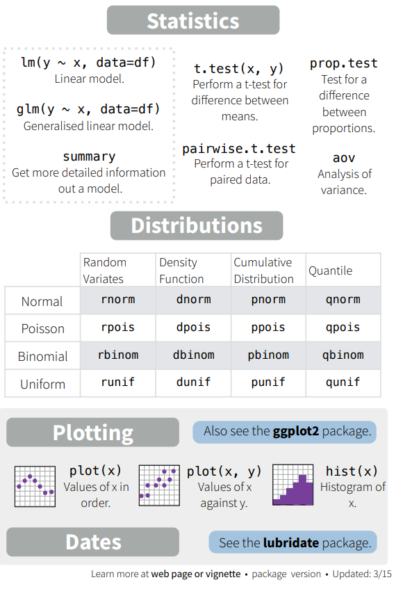

*Snippet from Resource 4*

## R Operations 2

### Importing Data sets

```r
# Import Data: Website
url <- "https://stat.ethz.ch/Teaching/Datasets/WBL/sport.dat"
d.sport <- read.table(url, header = TRUE)
head(d.sport)
```

```
##            weit kugel hoch  disc stab speer punkte
## OBRIEN     7.57 15.66  207 48.78  500 66.90   8824
## BUSEMANN   8.07 13.60  204 45.04  480 66.86   8706
## DVORAK     7.60 15.82  198 46.28  470 70.16   8664
## FRITZ      7.77 15.31  204 49.84  510 65.70   8644
## HAMALAINEN 7.48 16.32  198 49.62  500 57.66   8613
## NOOL       7.88 14.01  201 42.98  540 65.48   8543
```

```r
# Setting the Working Directory
# Use:
getwd() #Prints the current working directory
```

```
## [1] "D:/2025 MEng Transportation/SHC 798 R-Proj"
```

```r
# setwd("D:/2025 MEng Transportation/SHC 798 R-Proj") ~ Sets the working directory
# Alternatively, use “Session” → “Set Working Directory” → “Choose Directory…”
# Import Data: Files
  # - Different ways depending on the format (csv, txt, xlsx, etc.)
  # - Alternative: use the “Import Dataset” tool in RStudio (upper-right panel)
# Save data or write data to a file
  # - Text files
  # - Excel files: use CSV
```

### R Objects & Indexing

```r
# R Objects: Data frames (Most essential)
str(d.sport)
```

```
## 'data.frame':    15 obs. of  7 variables:
##  $ weit  : num  7.57 8.07 7.6 7.77 7.48 7.88 7.64 7.61 7.27 7.49 ...
##  $ kugel : num  15.7 13.6 15.8 15.3 16.3 ...
##  $ hoch  : int  207 204 198 204 198 201 195 213 207 204 ...
##  $ disc  : num  48.8 45 46.3 49.8 49.6 ...
##  $ stab  : int  500 480 470 510 500 540 540 520 470 470 ...
##  $ speer : num  66.9 66.9 70.2 65.7 57.7 ...
##  $ punkte: int  8824 8706 8664 8644 8613 8543 8422 8318 8307 8300 ...
```

```r
# R Objects: Vectors
  # (e.g., a column from the data set d.sport)
kugel <- d.sport$kugel
str(kugel)
```

```
##  num [1:15] 15.7 13.6 15.8 15.3 16.3 ...
```

```r
participant <- rownames(d.sport)
str(participant)
```

```
##  chr [1:15] "OBRIEN" "BUSEMANN" "DVORAK" "FRITZ" "HAMALAINEN" "NOOL" ...
```

```r
# Select elements
participant[4]
```

```
## [1] "FRITZ"
```

```r
d.sport[c(3,6,4), c(1:3,7)]
```

```
##        weit kugel hoch punkte
## DVORAK 7.60 15.82  198   8664
## NOOL   7.88 14.01  201   8543
## FRITZ  7.77 15.31  204   8644
```

```r
d.sport["FRITZ", ]
```

```
##       weit kugel hoch  disc stab speer punkte
## FRITZ 7.77 15.31  204 49.84  510  65.7   8644
```

```r
# Accessing Parts of an Object
# To access only part of an object, use []
  # For vectors: myvector[x]
  # For two-dimensional objects, e.g. data frames or matrices: mydata.frame[x,y]
d.sport[ , ]
```

```
##            weit kugel hoch  disc stab speer punkte
## OBRIEN     7.57 15.66  207 48.78  500 66.90   8824
## BUSEMANN   8.07 13.60  204 45.04  480 66.86   8706
## DVORAK     7.60 15.82  198 46.28  470 70.16   8664
## FRITZ      7.77 15.31  204 49.84  510 65.70   8644
## HAMALAINEN 7.48 16.32  198 49.62  500 57.66   8613
## NOOL       7.88 14.01  201 42.98  540 65.48   8543
## ZMELIK     7.64 13.53  195 43.44  540 67.20   8422
## GANIYEV    7.61 14.71  213 44.86  520 53.70   8318
## PENALVER   7.27 16.91  207 48.92  470 57.08   8307
## HUFFINS    7.49 15.57  204 48.72  470 60.62   8300
## PLAZIAT    7.82 14.85  204 45.34  490 52.18   8282
## MAGNUSSON  7.28 15.52  195 43.78  480 61.10   8274
## SMITH      7.47 16.97  195 49.54  500 64.34   8271
## MUELLER    7.25 14.69  195 45.90  510 66.10   8253
## CHMARA     7.75 14.51  210 42.60  490 54.84   8249
```

```r
c(1,3,7)
```

```
## [1] 1 3 7
```

```r
1:10
```

```
##  [1]  1  2  3  4  5  6  7  8  9 10
```

```r
d.sport[1:10, ]
```

```
##            weit kugel hoch  disc stab speer punkte
## OBRIEN     7.57 15.66  207 48.78  500 66.90   8824
## BUSEMANN   8.07 13.60  204 45.04  480 66.86   8706
## DVORAK     7.60 15.82  198 46.28  470 70.16   8664
## FRITZ      7.77 15.31  204 49.84  510 65.70   8644
## HAMALAINEN 7.48 16.32  198 49.62  500 57.66   8613
## NOOL       7.88 14.01  201 42.98  540 65.48   8543
## ZMELIK     7.64 13.53  195 43.44  540 67.20   8422
## GANIYEV    7.61 14.71  213 44.86  520 53.70   8318
## PENALVER   7.27 16.91  207 48.92  470 57.08   8307
## HUFFINS    7.49 15.57  204 48.72  470 60.62   8300
```

```r
d.sport[-c(1, 3,7), ] #negative indices are excluded
```

```
##            weit kugel hoch  disc stab speer punkte
## BUSEMANN   8.07 13.60  204 45.04  480 66.86   8706
## FRITZ      7.77 15.31  204 49.84  510 65.70   8644
## HAMALAINEN 7.48 16.32  198 49.62  500 57.66   8613
## NOOL       7.88 14.01  201 42.98  540 65.48   8543
## GANIYEV    7.61 14.71  213 44.86  520 53.70   8318
## PENALVER   7.27 16.91  207 48.92  470 57.08   8307
## HUFFINS    7.49 15.57  204 48.72  470 60.62   8300
## PLAZIAT    7.82 14.85  204 45.34  490 52.18   8282
## MAGNUSSON  7.28 15.52  195 43.78  480 61.10   8274
## SMITH      7.47 16.97  195 49.54  500 64.34   8271
## MUELLER    7.25 14.69  195 45.90  510 66.10   8253
## CHMARA     7.75 14.51  210 42.60  490 54.84   8249
```

```r
d.sport[ , 2:3]
```

```
##            kugel hoch
## OBRIEN     15.66  207
## BUSEMANN   13.60  204
## DVORAK     15.82  198
## FRITZ      15.31  204
## HAMALAINEN 16.32  198
## NOOL       14.01  201
## ZMELIK     13.53  195
## GANIYEV    14.71  213
## PENALVER   16.91  207
## HUFFINS    15.57  204
## PLAZIAT    14.85  204
## MAGNUSSON  15.52  195
## SMITH      16.97  195
## MUELLER    14.69  195
## CHMARA     14.51  210
```

```r
d.sport[c(1,3,6), 2:3]
```

```
##        kugel hoch
## OBRIEN 15.66  207
## DVORAK 15.82  198
## NOOL   14.01  201
```

```r
# Function Calls
mean(kugel)
```

```
## [1] 15.19867
```

```r
quantile(kugel)
```

```
##    0%   25%   50%   75%  100%
## 13.53 14.60 15.31 15.74 16.97
```

```r
quantile(kugel,probs = c(.75, 0.9))
```

```
##    75%    90%
## 15.740 16.674
```

```r
# Functions consist of mandatory and optional arguments:
  # mean(x, trim = 0, na.rm = FALSE, …)
  # x: mandatory argument
  # trim: optional argument, default is 0
  # na.rm: optional argument, default is FALSE

# The arguments of a function have a defined order and each argument has its own unique name
mean(x = kugel, na.rm = TRUE)
```

```
## [1] 15.19867
```

```r
mean(x = kugel, ,TRUE)
```

```
## [1] 15.19867
```

```r
# Useful Functions
nrow(d.sport)
```

```
## [1] 15
```

```r
ncol(d.sport)
```

```
## [1] 7
```

```r
dim(d.sport)
```

```
## [1] 15  7
```

```r
summary(d.sport)
```

```
##       weit           kugel            hoch            disc            stab
##  Min.   :7.250   Min.   :13.53   Min.   :195.0   Min.   :42.60   Min.   :470
##  1st Qu.:7.475   1st Qu.:14.60   1st Qu.:196.5   1st Qu.:44.32   1st Qu.:480
##  Median :7.600   Median :15.31   Median :204.0   Median :45.90   Median :500
##  Mean   :7.597   Mean   :15.20   Mean   :202.0   Mean   :46.38   Mean   :498
##  3rd Qu.:7.760   3rd Qu.:15.74   3rd Qu.:205.5   3rd Qu.:48.85   3rd Qu.:510
##  Max.   :8.070   Max.   :16.97   Max.   :213.0   Max.   :49.84   Max.   :540
##      speer           punkte
##  Min.   :52.18   Min.   :8249
##  1st Qu.:57.37   1st Qu.:8278
##  Median :64.34   Median :8318
##  Mean   :61.99   Mean   :8445
##  3rd Qu.:66.48   3rd Qu.:8628
##  Max.   :70.16   Max.   :8824
```

```r
# apply(d.sport)
head(d.sport)
```

```
##            weit kugel hoch  disc stab speer punkte
## OBRIEN     7.57 15.66  207 48.78  500 66.90   8824
## BUSEMANN   8.07 13.60  204 45.04  480 66.86   8706
## DVORAK     7.60 15.82  198 46.28  470 70.16   8664
## FRITZ      7.77 15.31  204 49.84  510 65.70   8644
## HAMALAINEN 7.48 16.32  198 49.62  500 57.66   8613
## NOOL       7.88 14.01  201 42.98  540 65.48   8543
```

```r
tail(d.sport)
```

```
##           weit kugel hoch  disc stab speer punkte
## HUFFINS   7.49 15.57  204 48.72  470 60.62   8300
## PLAZIAT   7.82 14.85  204 45.34  490 52.18   8282
## MAGNUSSON 7.28 15.52  195 43.78  480 61.10   8274
## SMITH     7.47 16.97  195 49.54  500 64.34   8271
## MUELLER   7.25 14.69  195 45.90  510 66.10   8253
## CHMARA    7.75 14.51  210 42.60  490 54.84   8249
```

### R Packages

```r
#install.packages("MASS")
#require(MASS) # for every R Session
#library(MASS) # or use this
```

o List of all packages: http://cran.r-project.org/web/packages/

o By topic: http://cran.r-project.org/web/views/

o Ask Google / ChatGPT / GroK

### Missing Values

```r
d.sport.NA <- d.sport
d.sport.NA[2, "kugel"] <- NA
d.sport.NA[3, "hoch"] <- -999
# missing values are coded as NA (not available) and are treated in a special way, e.g. is.na():
is.na(d.sport.NA) #one logical value per element
```

```
##             weit kugel  hoch  disc  stab speer punkte
## OBRIEN     FALSE FALSE FALSE FALSE FALSE FALSE  FALSE
## BUSEMANN   FALSE  TRUE FALSE FALSE FALSE FALSE  FALSE
## DVORAK     FALSE FALSE FALSE FALSE FALSE FALSE  FALSE
## FRITZ      FALSE FALSE FALSE FALSE FALSE FALSE  FALSE
## HAMALAINEN FALSE FALSE FALSE FALSE FALSE FALSE  FALSE
## NOOL       FALSE FALSE FALSE FALSE FALSE FALSE  FALSE
## ZMELIK     FALSE FALSE FALSE FALSE FALSE FALSE  FALSE
## GANIYEV    FALSE FALSE FALSE FALSE FALSE FALSE  FALSE
## PENALVER   FALSE FALSE FALSE FALSE FALSE FALSE  FALSE
## HUFFINS    FALSE FALSE FALSE FALSE FALSE FALSE  FALSE
## PLAZIAT    FALSE FALSE FALSE FALSE FALSE FALSE  FALSE
## MAGNUSSON  FALSE FALSE FALSE FALSE FALSE FALSE  FALSE
## SMITH      FALSE FALSE FALSE FALSE FALSE FALSE  FALSE
## MUELLER    FALSE FALSE FALSE FALSE FALSE FALSE  FALSE
## CHMARA     FALSE FALSE FALSE FALSE FALSE FALSE  FALSE
```

```r
sum(is.na(d.sport.NA)) # adds up the TRUE elements
```

```
## [1] 1
```

```r
which(is.na(d.sport.NA), arr.ind = TRUE) # where are the NA's
```

```
##          row col
## BUSEMANN   2   2
```

```r
# Specify missing values after reading in the data:
d.sport.NA[d.sport.NA == -999] <- NA

# Many functions have an argument to handle missing values, e.g. na.rm, na.omit:
sum(d.sport.NA$kugel)
```

```
## [1] NA
```

```r
sum(d.sport.NA$kugel, na.rm = TRUE)
```

```
## [1] 214.38
```

```r
na.omit(d.sport.NA)
```

```
##            weit kugel hoch  disc stab speer punkte
## OBRIEN     7.57 15.66  207 48.78  500 66.90   8824
## FRITZ      7.77 15.31  204 49.84  510 65.70   8644
## HAMALAINEN 7.48 16.32  198 49.62  500 57.66   8613
## NOOL       7.88 14.01  201 42.98  540 65.48   8543
## ZMELIK     7.64 13.53  195 43.44  540 67.20   8422
## GANIYEV    7.61 14.71  213 44.86  520 53.70   8318
## PENALVER   7.27 16.91  207 48.92  470 57.08   8307
## HUFFINS    7.49 15.57  204 48.72  470 60.62   8300
## PLAZIAT    7.82 14.85  204 45.34  490 52.18   8282
## MAGNUSSON  7.28 15.52  195 43.78  480 61.10   8274
## SMITH      7.47 16.97  195 49.54  500 64.34   8271
## MUELLER    7.25 14.69  195 45.90  510 66.10   8253
## CHMARA     7.75 14.51  210 42.60  490 54.84   8249
```

## Basic Graphics

```r
# The Plot Function: only 1 mandatory argument i.e., x. The 2nd most important one is y.
  # many optional arguments [col,pch,main,cex, ...]
  # use function par (?par) to set or query graphical parameters

data(iris)
iris
```

```
##     Sepal.Length Sepal.Width Petal.Length Petal.Width    Species
## 1            5.1         3.5          1.4         0.2     setosa
## 2            4.9         3.0          1.4         0.2     setosa
## 3            4.7         3.2          1.3         0.2     setosa
## 4            4.6         3.1          1.5         0.2     setosa
## 5            5.0         3.6          1.4         0.2     setosa
## 6            5.4         3.9          1.7         0.4     setosa
## 7            4.6         3.4          1.4         0.3     setosa
## 8            5.0         3.4          1.5         0.2     setosa
## 9            4.4         2.9          1.4         0.2     setosa
## 10           4.9         3.1          1.5         0.1     setosa
## 11           5.4         3.7          1.5         0.2     setosa
## 12           4.8         3.4          1.6         0.2     setosa
## 13           4.8         3.0          1.4         0.1     setosa
## 14           4.3         3.0          1.1         0.1     setosa
```

[output cut: 136 more lines]

```r
str(iris)
```

```
## 'data.frame':    150 obs. of  5 variables:
##  $ Sepal.Length: num  5.1 4.9 4.7 4.6 5 5.4 4.6 5 4.4 4.9 ...
##  $ Sepal.Width : num  3.5 3 3.2 3.1 3.6 3.9 3.4 3.4 2.9 3.1 ...
##  $ Petal.Length: num  1.4 1.4 1.3 1.5 1.4 1.7 1.4 1.5 1.4 1.5 ...
##  $ Petal.Width : num  0.2 0.2 0.2 0.2 0.2 0.4 0.3 0.2 0.2 0.1 ...
##  $ Species     : Factor w/ 3 levels "setosa","versicolor",..: 1 1 1 1 1 1 1 1 1 1 ...
```

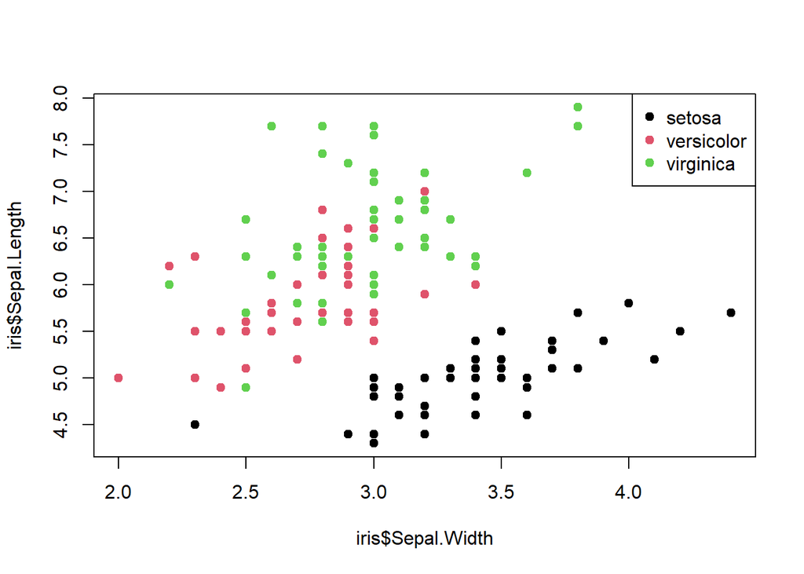

```r
# A factor represents categorical values with different "levels"
# High-level plotting function: opens a plot
plot(x = iris$Sepal.Width, y =iris$Sepal.Length, col = iris[ , "Species"], pch = 19)

#Low-level plotting functions: add to an existing plot
legend("topright", legend = levels(iris[ , "Species"]), pch = 19, col = 1:3) # adds legend
```

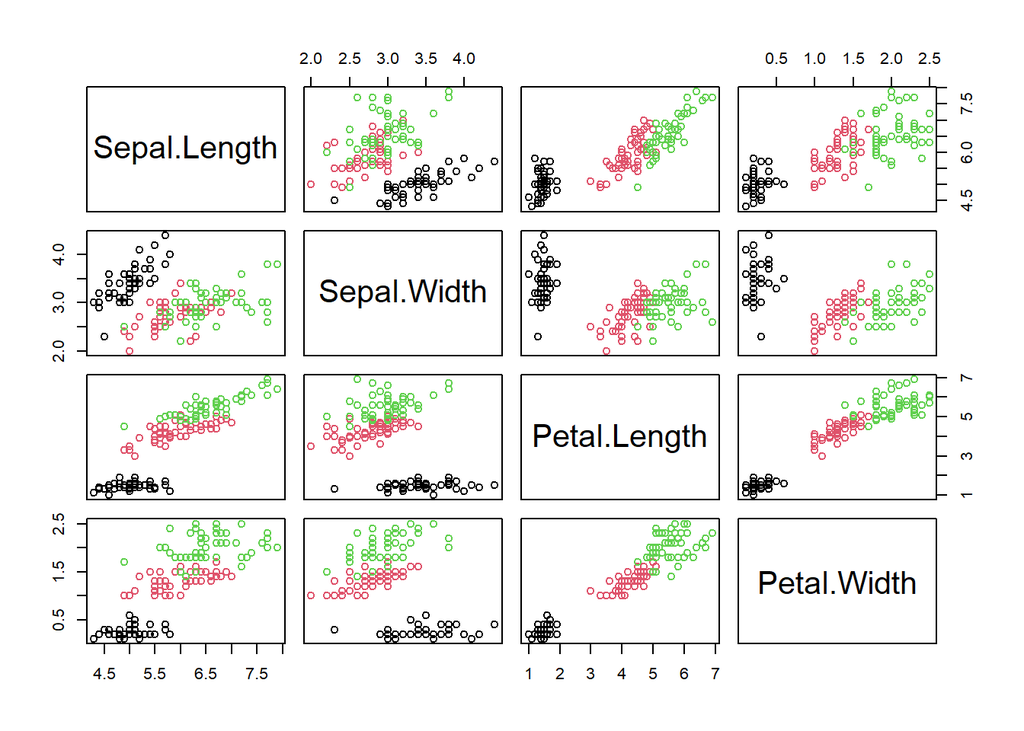

```r
# In an Rmd file such as this one, you need to call both the plot() & legend() functions at the same time. Or they should be in the same line of code

pairs(iris[ , -5], col = iris[ , 5])
```

### Arguments of plot

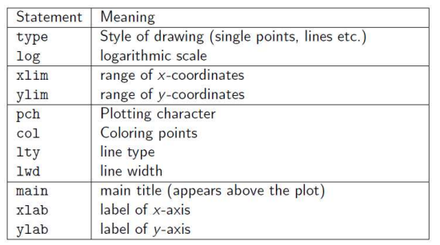

**Plot Arguments**

**Three categories of R graphics functions:**

• High-level plotting functions such as plot() to generate a new graphics display.

• Low-level plotting functions such as legend() to add further graphical elements to an existing plot.

• Interactive functions such as identify() to amend or collect information interactively from a plot.

**Low-level plotting functions**

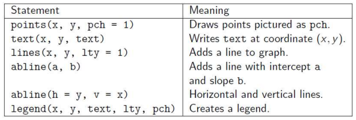

Low-level plotting functions

**Useful plot functions**

- plot, pairs, interaction.plot
- boxplot, hist
- plot3d

### Graphical Output

```r
pdf(file = "iris_plot.pdf") # open the graphics device
plot(Sepal.Length ~ Sepal.Width, data = iris)
# add anything else you want in your plots
dev.off() #close the graphic device
```

Several plots in one graphical window: splits the graphical window into 3 rows and 2 columns.

```r
par(mfrow=c(3,2))
```

**Other Graphics: in lattice**

The lattice package functions: good for repeating graphs for various groups. See the [**Lattice Graphs in R**](http://www.statmethods.net/advgraphs/trellis.html) (at http://www.statmethods.net/advgraphs/trellis.html) for more information.

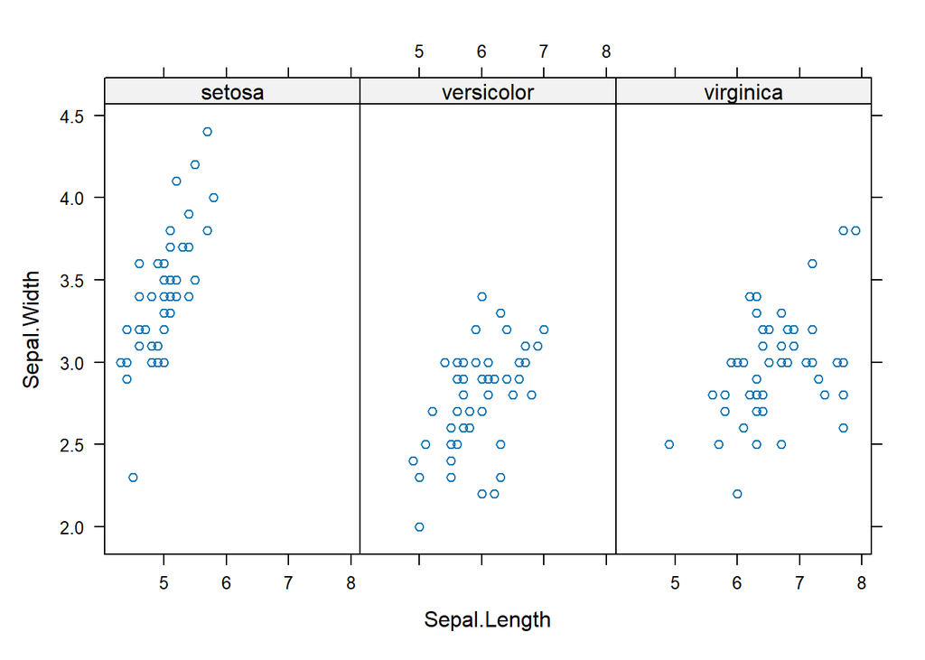

```r
pacman::p_load(lattice)
xyplot(Sepal.Width ~ Sepal.Length | Species, data = iris)
```

**Other Graphics: in ggplot2**

[**ggplot2**](https://ggplot2.org) package: very flexible, based on grammar of graphics.

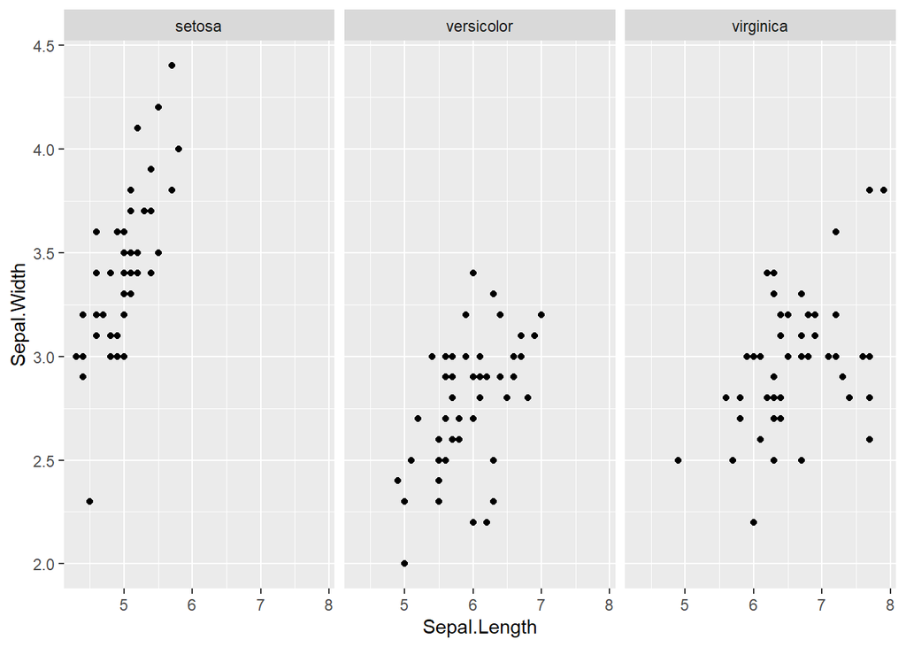

```r
pacman::p_load(ggplot2)
ggplot(data = iris, aes(x = Sepal.Length, y = Sepal.Width)) + facet_grid(rows = ~ Species) + geom_point()
```

## Hypothesis Testing

Approach: Hypothesis testing in 6 steps:

Hypothesis Tests – An Example

```r
# Is the sepal length of versicolor different to that of virginica? Let’s use a *t-Test and a *Wilcoxon rank-sum test.
testdata <- iris[iris$Species != "setosa", c("Sepal.Length", "Species")]
testdata$Species <- droplevels(testdata$Species)
str(testdata) # prepare and check the data
```

```
## 'data.frame':    100 obs. of  2 variables:
##  $ Sepal.Length: num  7 6.4 6.9 5.5 6.5 5.7 6.3 4.9 6.6 5.2 ...
##  $ Species     : Factor w/ 2 levels "versicolor","virginica": 1 1 1 1 1 1 1 1 1 1 ...
```

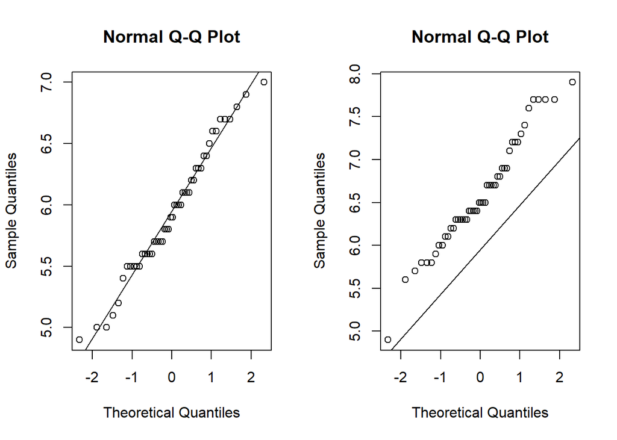

```r
# Check normality assumption of t-Test using QQ-Plot:
versi.id <- testdata$Species == "versicolor"
par(mfrow=c(1,2))
qqnorm(testdata$Sepal.Length[versi.id]); qqline(testdata$Sepal.Length[versi.id])
qqnorm(testdata$Sepal.Length[!versi.id]); qqline(testdata$Sepal.Length[versi.id])
```

```r
# Two-sample t-test:
versi.id <- testdata$Species == "versicolor"
t.test(x =testdata$Sepal.Length[versi.id], y = testdata$Sepal.Length[!versi.id], var.equal = TRUE)
```

```
##
##  Two Sample t-test
##
## data:  testdata$Sepal.Length[versi.id] and testdata$Sepal.Length[!versi.id]
## t = -5.6292, df = 98, p-value = 1.725e-07
## alternative hypothesis: true difference in means is not equal to 0
## 95 percent confidence interval:
##  -0.8818516 -0.4221484
## sample estimates:
## mean of x mean of y
##     5.936     6.588
```

```r
# T-test rejects the null hypothesis at 5% significance level. Do not forget to visually check the normality assumptions (QQ-plot)
```

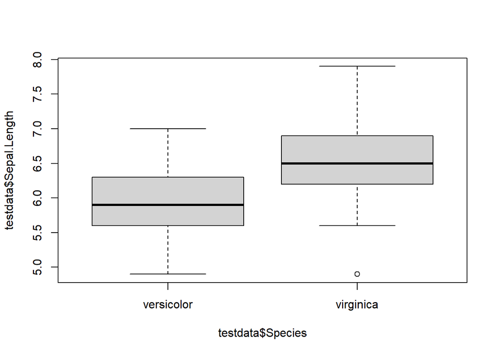

```r
# Check assumption of \*Wilcoxon Rank Test: same distribution, just a location shift.
boxplot(testdata$Sepal.Length ~ testdata$Species)
```

```r
# Now, perform the test:
versi.id <- testdata$Species == "versicolor"
wilcox.test(x =testdata$Sepal.Length[versi.id], y = testdata$Sepal.Length[!versi.id], var.equal = TRUE)
```

```
##
##  Wilcoxon rank sum test with continuity correction
##
## data:  testdata$Sepal.Length[versi.id] and testdata$Sepal.Length[!versi.id]
## W = 526, p-value = 5.869e-07
## alternative hypothesis: true location shift is not equal to 0
```

```r
# Wilcoxon Rank Test also rejects the null hypothesis at 5% significance level.
```

The **Wilcoxon Rank Test** is the *preferred* test for a two-sample statistical test.

### Hypothesis Tests - Summary

How to proceed:

- Formulate the null & alternative hypotheses
- Choose the appropriate test
- Collate data, i.e., do an experiment
- Look at data: plot(), pairs(), hist(), boxplot()
- Validate assumptions of test (e.g., T-test, Wilcoxon test)
- Carry out the test and interpret result

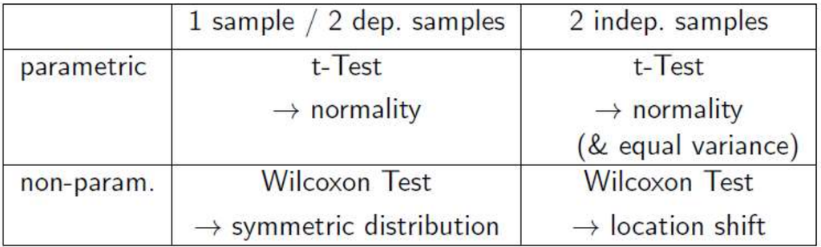

Hypothesis Tests

Hypothesis Tests – **Chi-squared test of independence**

- Hypothesis: H<sub>0</sub>: Independence of education and marriage status
- H<sub>A</sub>: Dependence of education and marriage status

```r
url <- "https://stat.ethz.ch/Teaching/Datasets/edu.txt"
d.edu <- read.table(url, header = TRUE)

# Cross-tables in R
# Count number of cases with same value:
table(d.edu[, "Married"])
```

```
##
## Married more Married once
##          205         1231
```

```r
# Cross-table
table(d.edu[, "Education"], d.edu[, "Married"])
```

```
##
##              Married more Married once
##   College              61          550
##   No College          144          681
```

```r
# Now we perform a Chi-squared test
chisq.test(d.edu[, "Education"], d.edu[, "Married"])
```

```
##
##  Pearson's Chi-squared test with Yates' continuity correction
##
## data:  d.edu[, "Education"] and d.edu[, "Married"]
## X-squared = 15.405, df = 1, p-value = 8.675e-05
```

```r
# Result: Reject H0, i.e. education and marriage are dependent.
```

## Correlation

```r
# Correlation
url1 <- "https://stat.ethz.ch/Teaching/Datasets/basischOhneNA.dat"
d.basisch <- read.table(url1, header = TRUE)
str(d.basisch)
```

```
## 'data.frame':    123 obs. of  4 variables:
##  $ ph    : num  7.33 7.69 7.9 8.14 7.62 ...
##  $ l.sar : num  0.0969 0.4393 1 1.316 0.0607 ...
##  $ height: num  5.91 5.2 4.4 4.5 6.05 6 5.35 5.55 4.95 5.2 ...
##  $ h.quad: num  34.9 27 19.4 20.2 36.6 ...
```

```r
# Calculate the (Pearson) correlation of ph and height:
cor(d.basisch$ph, d.basisch$height)
```

```
## [1] -0.6925717
```

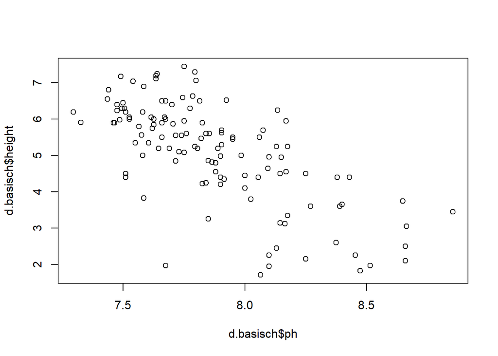

```r
# Corresponding plot:
plot(d.basisch$ph, d.basisch$height)
```

## Regression

### Simple Linear Regression (SLR)

From the d.basisch() data,

1. **Response variable**: *height* or h.quad: Height of trees or squared height, respectively.
2. **Possible explanatory variables**: *ph*: pH-values of soil and l.sar: log(sodium absorption ratio)

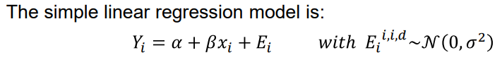

The Simple Linear Regression Model

Let us pick the variable ph as the explanatory variable.

```r
# Fit to data using lm:
fit <- lm(formula = height ~ ph, data = d.basisch)
summary(fit)
```

```
##
## Call:
## lm(formula = height ~ ph, data = d.basisch)
##
## Residuals:
##     Min      1Q  Median      3Q     Max
## -3.7020 -0.5471  0.0874  0.6663  2.0033
##
## Coefficients:
##             Estimate Std. Error t value Pr(>|t|)
## (Intercept)  28.7227     2.2395   12.82   <2e-16 ***
## ph           -3.0034     0.2844  -10.56   <2e-16 ***
## ---
## Signif. codes:  0 '***' 0.001 '**' 0.01 '*' 0.05 '.' 0.1 ' ' 1
##
## Residual standard error: 1.008 on 121 degrees of freedom
## Multiple R-squared:  0.4797, Adjusted R-squared:  0.4754
## F-statistic: 111.5 on 1 and 121 DF,  p-value: < 2.2e-16
```

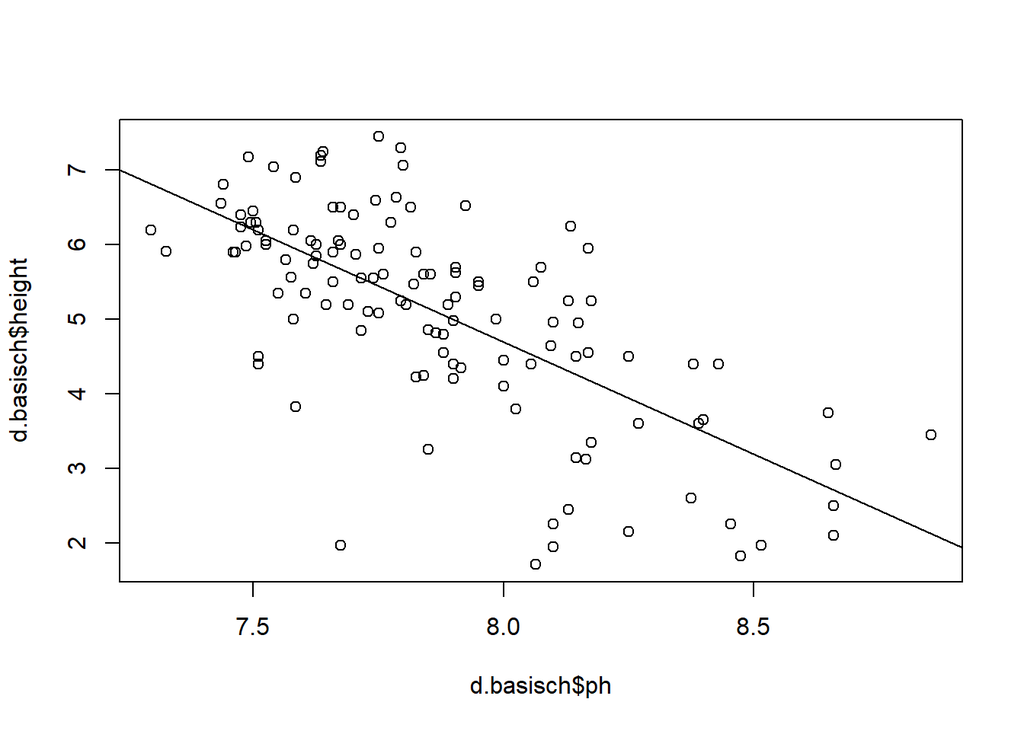

```
## integer(0)
```

```r
# Estimated equation: height = 28.7 – 3.0pH

# Drawing line into scatterplot:
plot(d.basisch$ph, d.basisch$height) + abline(fit)
```

```r
# Fit to data using lm:
fit <- lm(formula = height ~ ph, data = d.basisch)
summary(fit)
```

```
##
## Call:
## lm(formula = height ~ ph, data = d.basisch)
##
## Residuals:
##     Min      1Q  Median      3Q     Max
## -3.7020 -0.5471  0.0874  0.6663  2.0033
##
## Coefficients:
##             Estimate Std. Error t value Pr(>|t|)
## (Intercept)  28.7227     2.2395   12.82   <2e-16 ***
## ph           -3.0034     0.2844  -10.56   <2e-16 ***
## ---
## Signif. codes:  0 '***' 0.001 '**' 0.01 '*' 0.05 '.' 0.1 ' ' 1
##
## Residual standard error: 1.008 on 121 degrees of freedom
## Multiple R-squared:  0.4797, Adjusted R-squared:  0.4754
## F-statistic: 111.5 on 1 and 121 DF,  p-value: < 2.2e-16
```

```r
# Estimated equation: height = 28.7 – 3.0pH

# Drawing line into scatterplot:
plot(d.basisch$ph, d.basisch$height) + abline(fit)
```

[output not shown]

```
## integer(0)
```

#### SLR - Residual Analysis

Diagnostics plots are straightforward:

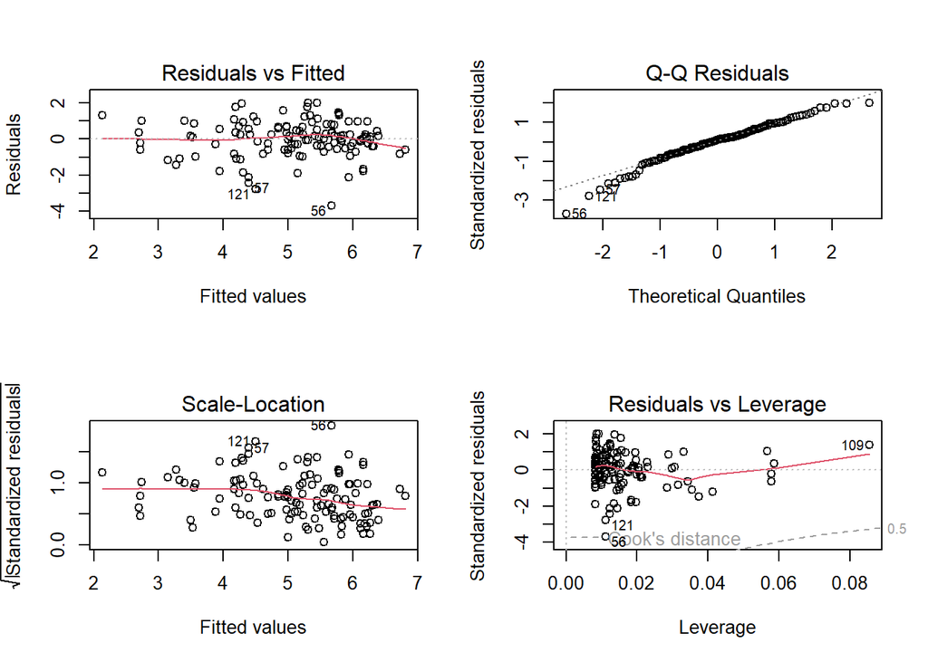

```r
par(mfrow = c(2,2))
plot(fit)
```

1. Tukey-Anscombe plot (is the variance of the errors Ei constant? Is the regression function correct?)
2. Q-Q plot (are the errors Ei normally distributed?)
3. Scale location plot (similar to Tukey-Anscombe plot)
4. Leverage plot (what points have a strong influence on the fit?)

Residual plots by hand:

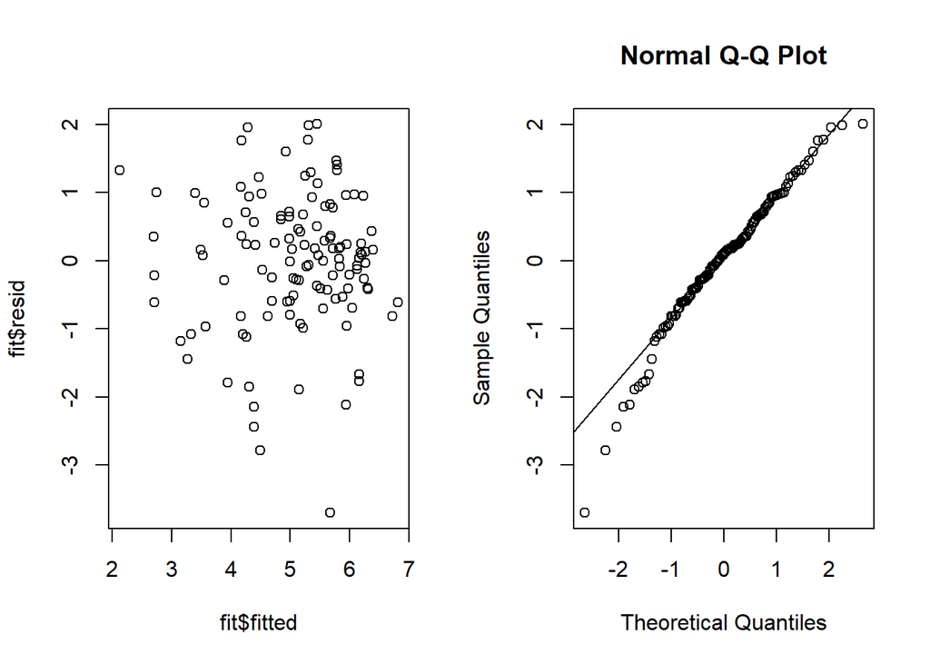

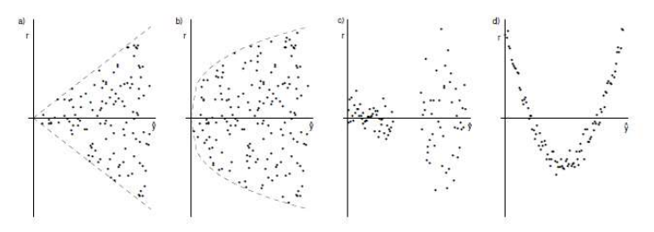

Some bad Tukey-Anscombe plots

```r
par(mfrow = c(1,2))
plot(fit$fitted,fit$resid)

#Tukey-Anscombe
qqnorm(fit$resid) #quantil-Quantil Plot
qqline(fit$resid) # adds the diagonal line
```

### Multiple Linear Regression

Expand the simple linear model to more than one explanatory variable.

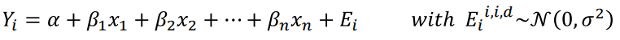

The Multiple Linear Regression Model

```r
# Fit the model with lm
fitm <- lm(height ~ ph + l.sar, data = d.basisch)
summary(fitm)
```

```
##
## Call:
## lm(formula = height ~ ph + l.sar, data = d.basisch)
##
## Residuals:
##     Min      1Q  Median      3Q     Max
## -4.1314 -0.4911  0.0849  0.6488  2.4754
##
## Coefficients:
##             Estimate Std. Error t value Pr(>|t|)
## (Intercept)  26.9466     2.7445   9.818  < 2e-16 ***
## ph           -2.7558     0.3603  -7.649  5.6e-12 ***
## l.sar        -0.2519     0.2255  -1.117    0.266
## ---
## Signif. codes:  0 '***' 0.001 '**' 0.01 '*' 0.05 '.' 0.1 ' ' 1
##
## Residual standard error: 1.007 on 120 degrees of freedom
## Multiple R-squared:  0.485,  Adjusted R-squared:  0.4764
## F-statistic: 56.51 on 2 and 120 DF,  p-value: < 2.2e-16
```

#### MLR - Residual Analysis

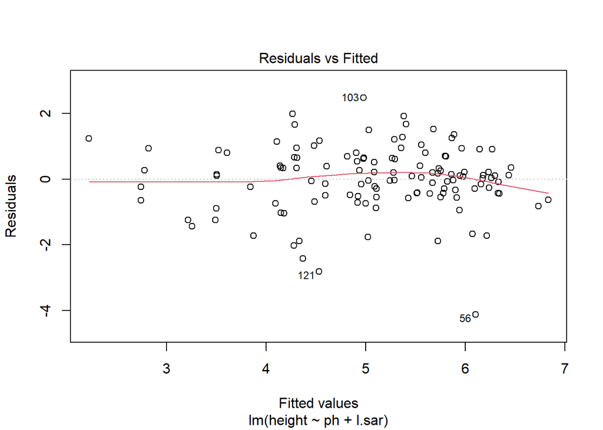

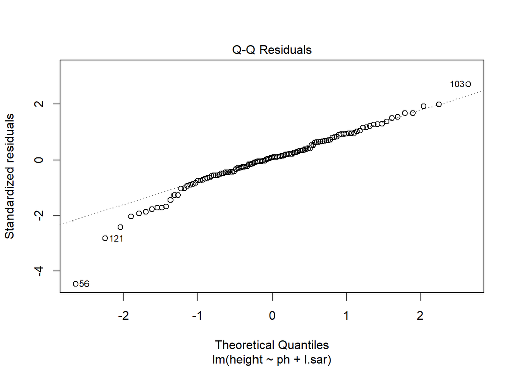

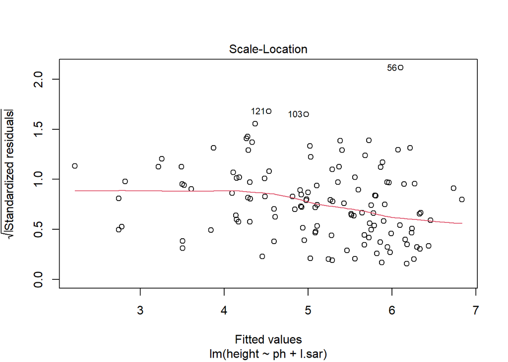

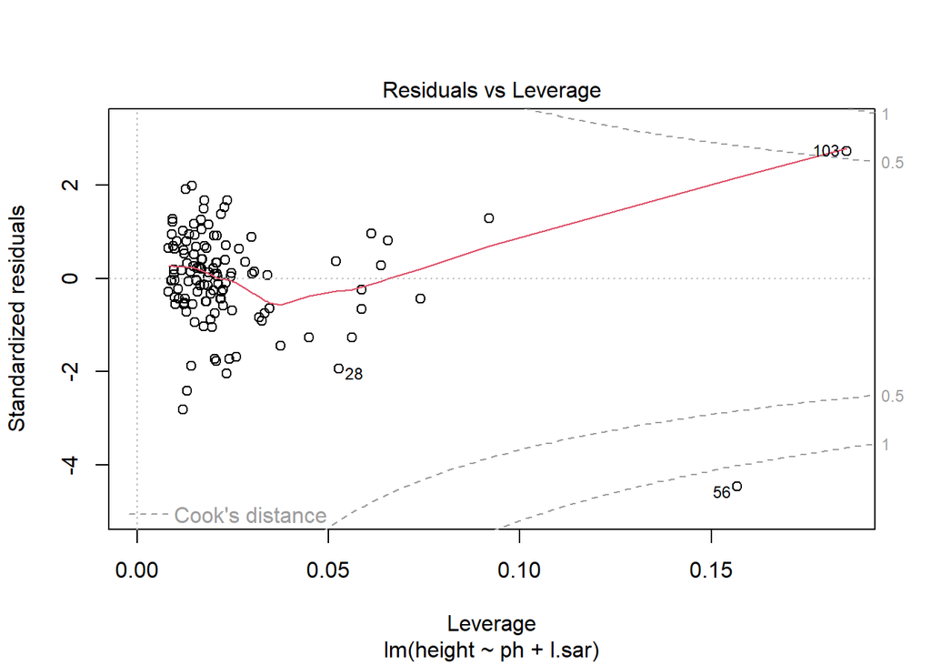

```r
# Look at the same plots as for simple linear regression
plot(fitm)
```

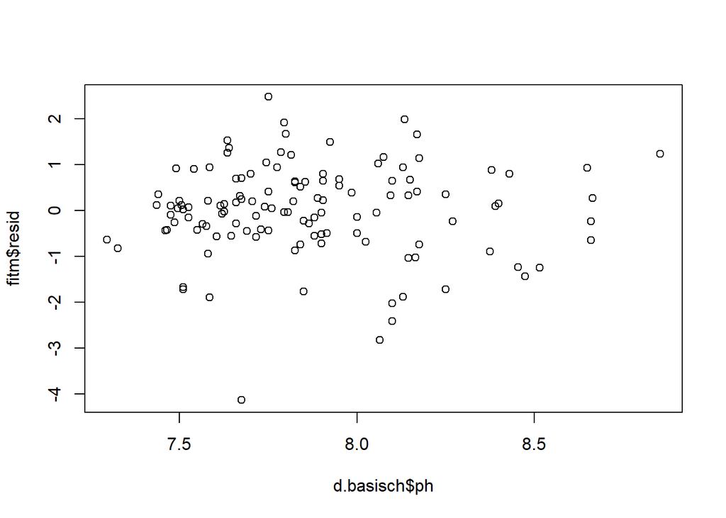

```r
# It may help to plot the explanatory variables against the residuals.
plot(d.basisch$ph, fitm$resid)
```

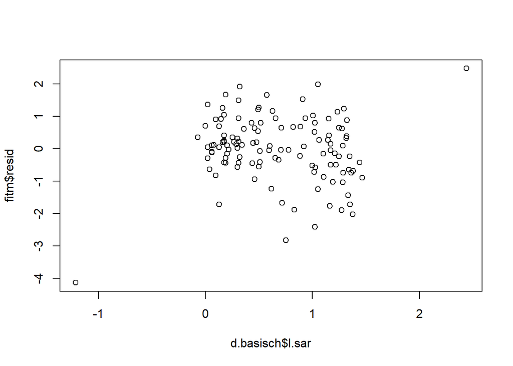

```r
plot(d.basisch$l.sar, fitm$resid)
```